# Obesidad

1. Se estarán importando los datos del archivo de obesidad de la misma forma como en la lectura de aprendizaje estadístico

```python
import pandas as pd
data = pd.read_csv("Obesidad.csv")
print(data.head(10))
```

```
     Sexo  Edad  Estatura  Peso FamiliarConSobrepeso ComeMuchasCalorias  \
0  Female  21.0      1.62  64.0                  yes                 no
1  Female  21.0      1.52  56.0                  yes                 no
2    Male  23.0      1.80  77.0                  yes                 no
3    Male  27.0      1.80  87.0                   no                 no
4    Male  22.0      1.78  89.8                   no                 no
5    Male  29.0      1.62  53.0                   no                yes
6  Female  23.0      1.50  55.0                  yes                yes
7    Male  22.0      1.64  53.0                   no                 no
8    Male  24.0      1.78  64.0                  yes                yes
9    Male  22.0      1.72  68.0                  yes                yes

   ComeVegetales Fumador  ConsumoDeAgua      NivelDeObesidad
0            2.0      no            2.0        Normal_Weight
1            3.0     yes            3.0        Normal_Weight
2            2.0      no            2.0        Normal_Weight
3            3.0      no            2.0   Overweight_Level_I
4            2.0      no            2.0  Overweight_Level_II
5            2.0      no            2.0        Normal_Weight
6            3.0      no            2.0        Normal_Weight
7            2.0      no            2.0        Normal_Weight
8            3.0      no            2.0        Normal_Weight
9            2.0      no            2.0        Normal_Weight
```

2. Otra variable a tener en cuenta que agregaría es la cantidad de minutos que pasan haciendo actividad física por semana ya que según National Heart, Lung and Blood Institute (2022) "La mayoría de los adultos necesitan al menos 150 minutos de actividad aeróbica por semana." así como "Los niños deben hacer 60 minutos de actividad aeróbica por día." Al saber esta información considero muy relevante saber este dato para ver si existe una relación con esta variable cuantitativa con el resto de los datos recompliados.
3. Si tuviera que decidir entre las variables anteriormente mencionadas para realizar un estudio de inferencia escogería el Nivel de Obesidad, esta siendo una variable cualitativa, ya que nos permitiría inferir si los demas datos están relacionados a tener o no obesidad, por ejemplo la relación entre las calorías con cuantas personas tienen Obesidad tipo 1,2 o 3

```python
#Se implementó una nueva forma de usar la función value_conts ya que al ponerlo con pandas marca error e investigando descubrí que esa función esta
#casi obsoleta
data.NivelDeObesidad.value_counts()
```

```
NivelDeObesidad
Obesity_Type_I         351
Obesity_Type_III       324
Obesity_Type_II        297
Overweight_Level_I     290
Overweight_Level_II    290
Normal_Weight          287
Insufficient_Weight    272
Name: count, dtype: int64
```

Se estará comparando la variable de estatura con el nivel de obesidad para el sexo femenino, esto ya que al investigar factores para identificar la obesidad mencionaban mucho la estatura como un rasgo importante, por lo que quiero ver la relación que existen entre estas variables y ver el nivel de obesidad que puede llegar a tener en esta población.

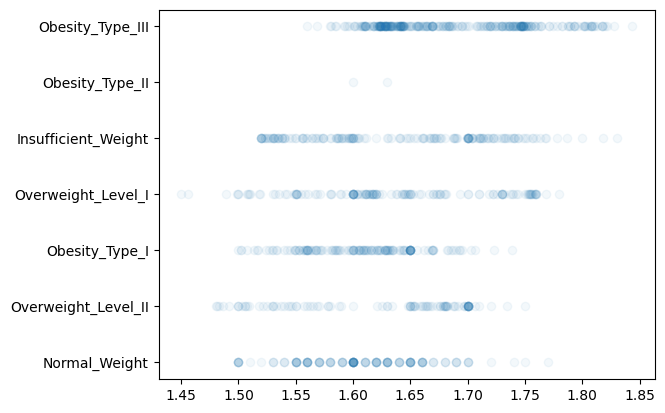

```python
#Función mágica, sirve para que las imágenes se desplieguen sin problema en las *Jupyter Notebooks*
%matplotlib inline
import matplotlib.pyplot as plt
plt.scatter(x = data.Estatura[data.Sexo=="Female"], y = data.NivelDeObesidad[data.Sexo=="Female"], alpha = 0.05)
plt.show()
```

Referencias: Causas y factores de riesgo | NHLBI, NIH. (2022, March 24). NHLBI, NIH. https://www.nhlbi.nih.gov/es/salud/sobrepeso-y-obesidad/causas

"Doy mi palabra que he realizado esta actividad con integridad académica."